G34-gliomas project [[source](https://github.com/fungenomics/G34-gliomas)]

# 01 - Interneuron pseudotemporal trajectory

16 September, 2020

# 1 Configuration

Configuration of project directory & analysis outputs:

**Show full config**

```r
library(here)

# Set up outputs
message("Document index: ", doc_id)
```

```
## Document index: 01
```

```r
# Specify where to save outputs
out        <- here(subdir, "output", doc_id); dir.create(out, recursive = TRUE)
figout     <- here(subdir, "figures", doc_id, "/"); dir.create(figout, recursive = TRUE)
cache      <- paste0("~/tmp/", basename(here()), "/", subdir, "/", doc_id, "/")

message("Cache: ", cache)
```

```
## Cache: ~/tmp/G34-gliomas/singlecell_normal/01/
```

The root directory of this project is:

```
## /lustre03/project/6004736/sjessa/from_beluga/HGG-G34/G34-gliomas
```

Outputs and figures will be saved at these paths, relative to project root:

```
## G34-gliomas/singlecell_normal/output/01
```

```
## G34-gliomas/singlecell_normal/figures/01//
```

Setting a random seed:

```r
set.seed(100)
```

# 2 Overview

To pinpoint the where along interneuron differentiation G34 HGGs may arise, we retrieve genes which are (1) upregulated by RNA-seq and H3K27-acetylated in G34 gliomas compared to other HGGs, and (2) downregulated by RNA-seq and H3K27-trimethylated in G34 gliomas compared to other HGGs, from the multi-omics analysis in the `bulk_transcriptome_epigenome` directory. We then interrogate the expression of these genes along the normal interneuron differentiation trajectory that we’ve constructed previously with monocle.

# 3 Libraries

```r
# Load libraries here
library(tidyr)
library(dplyr)
library(readr)
library(glue)
library(purrr)
library(cytobox)
library(magrittr)
library(pheatmap)
library(monocle)

source(here(subdir, "analysis/functions.R"))
```

# 4 Analysis

## 4.1 Cell type density along normal interneuron differentiation trajectory

First we load a table of pseudotime values per cell:

```r
# Clean up the cell names, which got mangled a bit due to additional prefixes
# when the Seurat objects were merged
tidy_cellnames <- function(pseudotime) {

    pseudotime %>%
        mutate(cell = case_when(
            grepl("e12|e15", cell) ~ paste0("__", cell),
            grepl("p0", cell) ~ paste0("__", cell),
            TRUE ~ cell
        )) %>%
        mutate(pseudotime = Pseudotime)

}

inhibitory_pseudotime <- read_tsv(here("reference_datasets/2019_Jessa/Jessa2019_inhibitory_neurons_pseudotime.txt")) %>%
    tidy_cellnames()
```

Next load the cell type identities for each cell:

```r
inhibitory_pseudotime$pseudotime %<>% scales::rescale(to = c(0, 100))

# Load the metadata for the joint forebrain and set the identities
forebrain_meta <- read_tsv(here("reference_datasets/2019_Jessa/Jessa2019_joint_forebrain_metadata.tsv"))
inhibitory_pseudotime <- left_join(inhibitory_pseudotime, forebrain_meta, by = c("cell" = "Cell"))
```

Finally, generate a density plot of each cell type along pseudotime, to represent the relative proportions of each cell type as differentiation proceeds:

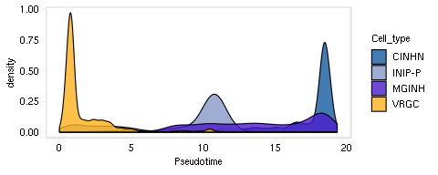

```r
# Grab cells in the clusters included in this Monocle analysis,
# and plot their density in pseuodtime
inhibitory_pseudotime %>%
    filter(grepl("VRGC|INIP|MGINH|CINH", ID_20190730_with_blacklist_and_refined)) %>%
    separate(ID_20190730_with_blacklist_and_refined,
             sep = "_",
             into = c("Sample", "Cell_type")) %>%
    rr_ggplot(aes(x = Pseudotime), plot_num = 1) +
    geom_density(aes(fill = Cell_type), alpha = 0.8, size = 0.4) +
    scale_fill_manual(values = c(
        "VRGC"   = "#ffb219",
        "INIP-P" = "#8798C8",
        "MGINH"  = "#4a1cc9",
        "CINHN"  = "#135ca0"
    )) +
    theme_min()
```

<sub>[figure/source data @ *G34-gliomas/singlecell_normal/figures/01//interneuron_differentiation_density_plot…*]</sub>

## 4.2 Plot genes of interest along pseudotime

```r
load(here("reference_datasets/2019_Jessa/Jessa2019_inhibitory_neurons.monocle.Rda"))

pal_pseudotime <- colorRampPalette(c("navy", "white", "red"))(n = 200)
```

One way to evaluate whether the genes which drive enrichment of fetal neuronal signatures vs. depletion of pediatric/adult signatures in G34 gliomas by GSEA are related to maturity is by checking their expression during normal differentiation. Get the genes from the GSEA analysis:

```r
signatures <- c("MGE newborn neurons 1", "Parvalbumin interneurons")

fgsea_df_idh_filt <- read_tsv(here("bulk_transcriptome_epigenome/output/02/fgsea_results_padj<0.01_IDH_top_le.tsv"))
```

```r
leading_edge <- fgsea_df_idh_filt %>%
    filter(Cell_type %in% signatures) %>%
    select(Cell_type, leadingEdge_top) %>%
    tibble::deframe() %>%
    map(~ .x %>% stringr::str_split(", ") %>% unlist() %>% hg2mm() %>% filter_NA())

leading_edge
```

```
## $`MGE newborn neurons 1`
##  [1] "Arx"           "Dlx6"          "Smarcd1"       "Plxna2"
##  [5] "Dcx"           "St8sia5"       "E030030I06Rik" "Dlx5"
##  [9] "Fam65b"        "Dlx2"          "Tmem2"         "Gad2"
## [13] "Dlx1"          "Pdgfd"         "Metap1d"       "Arl4d"
## [17] "Sox1"          "Ccser1"
##
## $`Parvalbumin interneurons`
##  [1] "Epha6"    "Fgf12"    "Nxph1"    "Gria4"    "Sparcl1"  "Cntnap5c"
##  [7] "Cntnap5b" "Cntnap5a" "Adcy8"    "Kcnab1"   "Frmd5"    "Plcxd3"
## [13] "Caln1"    "Kcnd2"    "Dner"     "Vwc2"     "Fam19a2"  "Shisa9"
## [19] "Ptchd4"
```

However, we only want to plot genes with reasonable mean exp in the clusters of this lineage, so that the smoothing makes sense:

```r
all_genes <- read_tsv(here("reference_datasets/2019_Jessa/Jessa2019_forebrain_gene_names.tsv")) %>%
    pull(genes)
```

```r
filter_by_mean_expr <- function(genes) {

    genes <- genes[genes %in% all_genes] %>% unique()

    # Check expression in all the clusters which comprise the cortical
    # inhibitory neuron lineages
    feather::read_feather(here("reference_datasets/2019_Jessa/Jessa2019_mean_expression.feather"),
                          c("Cluster", genes)) %>%
        gather(Gene, Mean_expression, 2:ncol(.)) %>%
        filter(grepl("^F", Cluster) & grepl("e12|e15|p0", Cluster)) %>%
        filter(grepl("INIP|INH|VRGC", Cluster)) %>%
        filter(Mean_expression > 0.1) %>%
        pull(Gene) %>%
        unique() %>%
        sort()

}

(leading_edge_filt <- map(leading_edge, ~ filter_by_mean_expr(.x)))
```

```
## $`MGE newborn neurons 1`
##  [1] "Arl4d"   "Arx"     "Dcx"     "Dlx1"    "Dlx2"    "Dlx5"    "Dlx6"
##  [8] "Fam65b"  "Gad2"    "Metap1d" "Plxna2"  "Smarcd1" "Sox1"    "Tmem2"
##
## $`Parvalbumin interneurons`
## [1] "Caln1"   "Dner"    "Fam19a2" "Frmd5"   "Gria4"   "Kcnd2"   "Nxph1"
## [8] "Plcxd3"  "Sparcl1"
```

```r
names(leading_edge_filt) <- gsub(" ", "_", names(leading_edge_filt))
```

Extract genes to examine in pseudotime from the transcriptome/epigenome analyses – we’ll gate genes based on high zK27Ac and low zK27me3, or vice versa:

```r
# Read in output of ChIP-seq analysis
multiomic_genes <- read_tsv(here("bulk_transcriptome_epigenome/output/03/DGE_and_histone_marks.tsv"))
multiomic_genes_top <- list("UP" = multiomic_genes %>%
                             filter(G34R.zK27ac > 0.6) %>%
                             pull(symbol) %>% hg2mm() %>% filter_NA(),
                         "DOWN" = multiomic_genes %>%
                             filter(G34R.zK27m3 > 0.6) %>%
                             pull(symbol) %>% hg2mm() %>% filter_NA())

(multiomic_genes_top_filt <- map(multiomic_genes_top, ~ filter_by_mean_expr(.x)))
```

```
## $UP
##  [1] "Cdca7l"  "Chic2"   "Dlx1"    "Dlx2"    "Dlx6"    "Efnb1"   "Elovl2"
##  [8] "Ephb2"   "Foxg1"   "Foxm1"   "Gad2"    "Gsx2"    "Ildr2"   "Insm1"
## [15] "Jag1"    "Npy"     "Nr2e1"   "Otx1"    "Pax6"    "Plk2"    "Prdm16"
## [22] "Sel1l3"  "Skida1"  "Slc10a4" "Sox1"    "Sp8"     "Tacc3"   "Tead2"
##
## $DOWN
##  [1] "Arhgdig" "Cadps"   "Chd5"    "Dlgap3"  "Igsf21"  "Jph3"    "Jph4"
##  [8] "Npas1"   "Ntrk2"   "Nxph1"   "Sertad4" "Sez6l2"  "Shank1"  "St8sia1"
```

```r
pseudotime_union <- list(
    # Newborn interneuron & upregulated genes
    "UP"   = unique(c(leading_edge_filt[[1]], multiomic_genes_top_filt[[1]])),

    # Postnatal interneuron & downregulated genes
    "DOWN" = unique(c(leading_edge_filt[[2]], multiomic_genes_top_filt[[2]])))

imap(pseudotime_union, ~ ordered_pseudotime_heatmap(monocle[.x,],
                                                    show_rownames = TRUE,
                                                    order_by_pseudotime = TRUE,
                                                    hmcols = pal_pseudotime,
                                                    prefix = glue("{figout}/pseudotime_heatmap{.y}")))
```

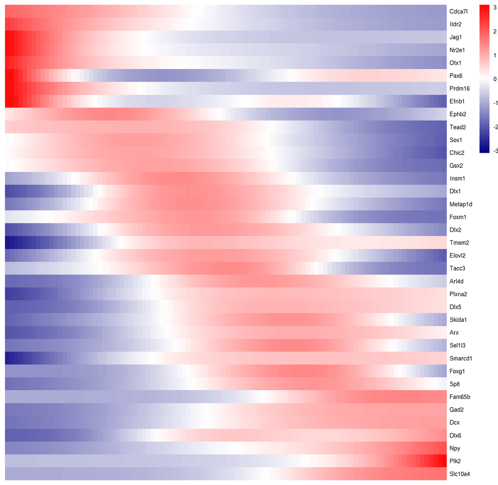

```r
knitr::include_graphics(glue("{figout}/pseudotime_heatmapUP.png"))
```

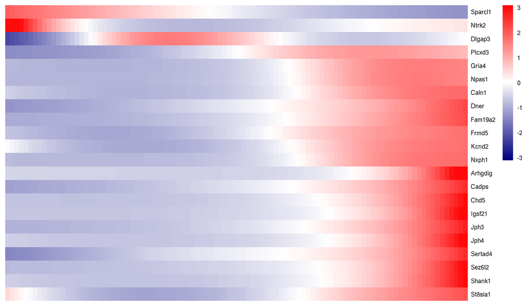

```r
knitr::include_graphics(glue("{figout}/pseudotime_heatmapDOWN.png"))
```

<sub>[figure/source data @ *G34-gliomas/singlecell_normal/figures/01//pseudotime_heatmap…*]</sub>

# 5 Reproducibility

This document was last rendered on:

```
## 2020-09-16 10:51:08
```

The git repository and last commit:

```
## Local:    master /lustre03/project/6004736/sjessa/from_beluga/HGG-G34/G34-gliomas
## Remote:   master @ origin (git@github.com:fungenomics/G34-gliomas.git)
## Head:     [feed0d9] 2020-09-16: Update lockfile (after installing monocle)
```

The random seed was set with `set.seed(100)`

A project of the Kleinman Lab at McGill University, using the [rr](https://github.com/sjessa/rr/) reproducible research template.  
[home](https://functionalgenomics.ca/) [GitHub](https://github.com/fungenomics/)